# Course Capstone Project: NLP

15/Mar/2018

## Introduction

The main goal of this capstone project is to build a Shiny application to predict the next word based on the preceding words.

The RSQLite database were made from three sources: blogs, news and twitter. Over 300,000 lines were randomly sampled from over 4 million lines of texts to build the text predictive model. The Database, source codes for text mining, exploratory data analysis, model building and this presentation can be found on [GitHub](https://github.com/Rohit1310/CourseraCapstone).

The R-Shiny App for this Course project is hosted on Shiny server [here](https://rohaki.shinyapps.io/prednext/).

## How to use the application

I have made a fairly simple to use application. Application usage steps are as follows:

1. Go to "Prediction" Tab
2. Write the sentence in the "Input Sentence" on the left
3. Click on the "Predict" button
4. The predicted worlds will be shown in the "Prediction" tab
5. Thereafter keep writing new worlds, the respective predicted word will be populated in the "Prediction" tab

## Algorithm

- The app used the N-gram model to predict the next word.
- The provided data was sampled then tokenized into unigrams, bigrams, trigrams, four-grams and stored in a RMySQlite database file.
- Katz's back off model and Good-Turing smoothing were used to predict the probability of unseen words.
- The model would search a match as per the length of input sentence in the n-gram database if a match was found, the predicted word would be returned based on the probability.
- If the length of the input is greater then three the model will extract the last three words and search a match in the 4-gram table of the database.

## First Look of the application

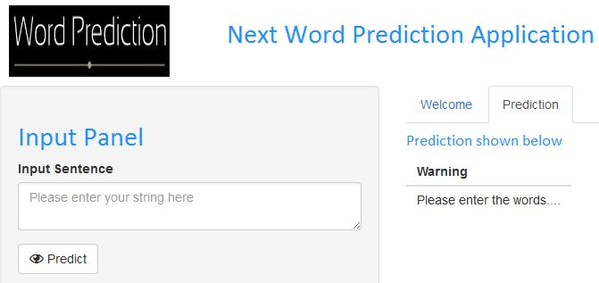